# Risk Factor Analysis

## Outcome Variable

**Outcome Variable:** stunted

## Predictor Variables

**Intervention Variable:** feducyrs

**Adjustment Set:**

unadjusted

## Stratifying Variables

The analysis was stratified on these variable(s):

- agecat
- studyid

The following strata were considered:

- agecat: 12 months, studyid: ki0047075b-MAL-ED
- agecat: 12 months, studyid: ki1000304b-SAS-FoodSuppl
- agecat: 12 months, studyid: ki1017093b-PROVIDE
- agecat: 12 months, studyid: ki1017093c-NIH-Crypto
- agecat: 12 months, studyid: ki1066203-TanzaniaChild2
- agecat: 12 months, studyid: ki1113344-GMS-Nepal
- agecat: 12 months, studyid: ki1126311-ZVITAMBO
- agecat: 12 months, studyid: ki1135781-COHORTS
- agecat: 12 months, studyid: ki1148112-LCNI-5
- agecat: 18 months, studyid: ki0047075b-MAL-ED
- agecat: 18 months, studyid: ki1000304b-SAS-FoodSuppl
- agecat: 18 months, studyid: ki1017093b-PROVIDE
- agecat: 18 months, studyid: ki1017093c-NIH-Crypto
- agecat: 18 months, studyid: ki1066203-TanzaniaChild2
- agecat: 18 months, studyid: ki1113344-GMS-Nepal
- agecat: 18 months, studyid: ki1126311-ZVITAMBO
- agecat: 18 months, studyid: ki1135781-COHORTS
- agecat: 18 months, studyid: ki1148112-LCNI-5
- agecat: 24 months, studyid: ki0047075b-MAL-ED
- agecat: 24 months, studyid: ki1017093b-PROVIDE
- agecat: 24 months, studyid: ki1017093c-NIH-Crypto
- agecat: 24 months, studyid: ki1066203-TanzaniaChild2
- agecat: 24 months, studyid: ki1113344-GMS-Nepal
- agecat: 24 months, studyid: ki1126311-ZVITAMBO
- agecat: 24 months, studyid: ki1135781-COHORTS
- agecat: 24 months, studyid: ki1148112-LCNI-5
- agecat: 3 months, studyid: ki0047075b-MAL-ED
- agecat: 3 months, studyid: ki1000304b-SAS-FoodSuppl
- agecat: 3 months, studyid: ki1017093b-PROVIDE
- agecat: 3 months, studyid: ki1017093c-NIH-Crypto
- agecat: 3 months, studyid: ki1066203-TanzaniaChild2
- agecat: 3 months, studyid: ki1113344-GMS-Nepal
- agecat: 3 months, studyid: ki1126311-ZVITAMBO
- agecat: 3 months, studyid: ki1135781-COHORTS
- agecat: 6 months, studyid: ki0047075b-MAL-ED
- agecat: 6 months, studyid: ki1000304b-SAS-FoodSuppl
- agecat: 6 months, studyid: ki1017093b-PROVIDE
- agecat: 6 months, studyid: ki1017093c-NIH-Crypto
- agecat: 6 months, studyid: ki1066203-TanzaniaChild2
- agecat: 6 months, studyid: ki1113344-GMS-Nepal
- agecat: 6 months, studyid: ki1126311-ZVITAMBO
- agecat: 6 months, studyid: ki1135781-COHORTS
- agecat: 6 months, studyid: ki1148112-LCNI-5
- agecat: 9 months, studyid: ki0047075b-MAL-ED
- agecat: 9 months, studyid: ki1000304b-SAS-FoodSuppl
- agecat: 9 months, studyid: ki1017093b-PROVIDE
- agecat: 9 months, studyid: ki1017093c-NIH-Crypto
- agecat: 9 months, studyid: ki1066203-TanzaniaChild2
- agecat: 9 months, studyid: ki1113344-GMS-Nepal
- agecat: 9 months, studyid: ki1126311-ZVITAMBO
- agecat: 9 months, studyid: ki1135781-COHORTS
- agecat: 9 months, studyid: ki1148112-LCNI-5
- agecat: Birth, studyid: ki0047075b-MAL-ED
- agecat: Birth, studyid: ki1017093c-NIH-Crypto
- agecat: Birth, studyid: ki1126311-ZVITAMBO
- agecat: Birth, studyid: ki1135781-COHORTS

### Dropped Strata

Some strata were dropped due to rare outcomes:

- agecat: Birth, studyid: ki1017093c-NIH-Crypto
- agecat: Birth, studyid: ki1126311-ZVITAMBO
- agecat: 3 months, studyid: ki1017093b-PROVIDE
- agecat: 3 months, studyid: ki1066203-TanzaniaChild2
- agecat: 3 months, studyid: ki1126311-ZVITAMBO
- agecat: 6 months, studyid: ki1017093b-PROVIDE
- agecat: 6 months, studyid: ki1066203-TanzaniaChild2
- agecat: 6 months, studyid: ki1126311-ZVITAMBO
- agecat: 9 months, studyid: ki1000304b-SAS-FoodSuppl
- agecat: 9 months, studyid: ki1017093b-PROVIDE
- agecat: 9 months, studyid: ki1066203-TanzaniaChild2
- agecat: 9 months, studyid: ki1126311-ZVITAMBO
- agecat: 12 months, studyid: ki1000304b-SAS-FoodSuppl
- agecat: 12 months, studyid: ki1017093b-PROVIDE
- agecat: 12 months, studyid: ki1066203-TanzaniaChild2
- agecat: 12 months, studyid: ki1126311-ZVITAMBO
- agecat: 18 months, studyid: ki1000304b-SAS-FoodSuppl
- agecat: 18 months, studyid: ki1017093b-PROVIDE
- agecat: 18 months, studyid: ki1066203-TanzaniaChild2
- agecat: 18 months, studyid: ki1126311-ZVITAMBO
- agecat: 24 months, studyid: ki1017093b-PROVIDE
- agecat: 24 months, studyid: ki1066203-TanzaniaChild2
- agecat: 24 months, studyid: ki1126311-ZVITAMBO

## Methods Detail

We’re interested in the causal parameters $E[Y_a]$ for all values of $a \in \mathcal{A}$. These parameters represent the mean outcome if, possibly contrary to fact, we intervened to set all units to have $A=a$. Under the randomization and positivity assumptions, these are identified by the statistical parameters $\psi_a=E_W[E_{Y|A,W}(Y|A=a,W)]$. In addition, we’re interested in the mean of $Y$, $E[Y]$ under no intervention (the observed mean). We will estimate these parameters by using SuperLearner to fit the relevant likelihood factors – $E_{Y|A,W}(Y|A=a,W)$ and $p(A=a|W)$, and then updating our likelihood fit using a joint TMLE.

For unadjusted analyses ($W=\{\}$), initial likelihoods were estimated using Lrnr_glm to estimate the simple $E(Y|A)$ and Lrnr_mean to estimate $p(A)$. For adjusted analyses, a small library containing Lrnr_glmnet, Lrnr_xgboost, and Lrnr_mean was used.

Having estimated these parameters, we will then use the delta method to estimate relative risks and attributable risks relative to a prespecified baseline level of $A$.

# Results Detail

## Results Plots

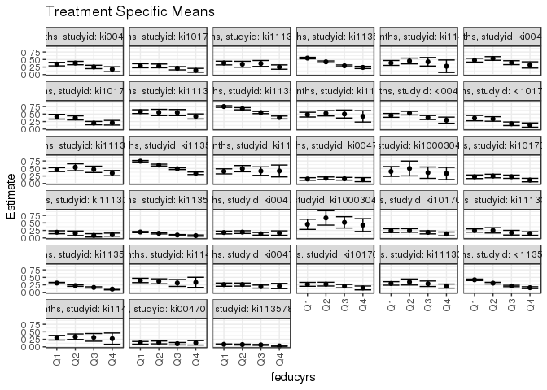

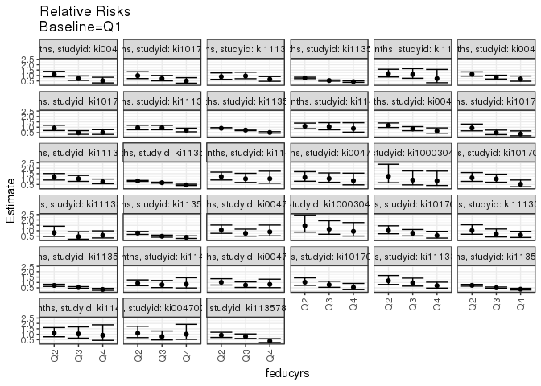

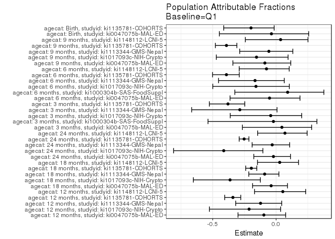

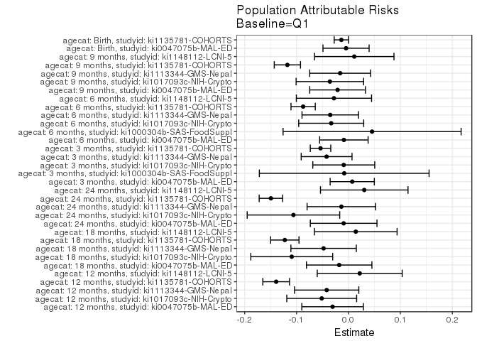

## Data Summary

| agecat | studyid | A | n | nA | nAY0 | nAY1 |
| --- | --- | --- | --- | --- | --- | --- |
| Birth | ki0047075b-MAL-ED | Q1 | 762 | 225 | 195 | 30 |
| Birth | ki0047075b-MAL-ED | Q2 | 762 | 226 | 193 | 33 |
| Birth | ki0047075b-MAL-ED | Q3 | 762 | 229 | 205 | 24 |
| Birth | ki0047075b-MAL-ED | Q4 | 762 | 82 | 71 | 11 |
| Birth | ki1000304b-SAS-FoodSuppl | Q1 | 0 | 0 | 0 | 0 |
| Birth | ki1000304b-SAS-FoodSuppl | Q2 | 0 | 0 | 0 | 0 |
| Birth | ki1000304b-SAS-FoodSuppl | Q3 | 0 | 0 | 0 | 0 |
| Birth | ki1000304b-SAS-FoodSuppl | Q4 | 0 | 0 | 0 | 0 |
| Birth | ki1017093b-PROVIDE | Q1 | 0 | 0 | 0 | 0 |
| Birth | ki1017093b-PROVIDE | Q2 | 0 | 0 | 0 | 0 |
| Birth | ki1017093b-PROVIDE | Q3 | 0 | 0 | 0 | 0 |
| Birth | ki1017093b-PROVIDE | Q4 | 0 | 0 | 0 | 0 |
| Birth | ki1017093c-NIH-Crypto | Q1 | 27 | 7 | 5 | 2 |
| Birth | ki1017093c-NIH-Crypto | Q2 | 27 | 9 | 8 | 1 |
| Birth | ki1017093c-NIH-Crypto | Q3 | 27 | 8 | 6 | 2 |
| Birth | ki1017093c-NIH-Crypto | Q4 | 27 | 3 | 3 | 0 |
| Birth | ki1066203-TanzaniaChild2 | Q1 | 0 | 0 | 0 | 0 |
| Birth | ki1066203-TanzaniaChild2 | Q2 | 0 | 0 | 0 | 0 |
| Birth | ki1066203-TanzaniaChild2 | Q3 | 0 | 0 | 0 | 0 |
| Birth | ki1066203-TanzaniaChild2 | Q4 | 0 | 0 | 0 | 0 |
| Birth | ki1113344-GMS-Nepal | Q1 | 0 | 0 | 0 | 0 |
| Birth | ki1113344-GMS-Nepal | Q2 | 0 | 0 | 0 | 0 |
| Birth | ki1113344-GMS-Nepal | Q3 | 0 | 0 | 0 | 0 |
| Birth | ki1113344-GMS-Nepal | Q4 | 0 | 0 | 0 | 0 |
| Birth | ki1126311-ZVITAMBO | Q1 | 3373 | 15 | 13 | 2 |
| Birth | ki1126311-ZVITAMBO | Q2 | 3373 | 23 | 23 | 0 |
| Birth | ki1126311-ZVITAMBO | Q3 | 3373 | 441 | 392 | 49 |
| Birth | ki1126311-ZVITAMBO | Q4 | 3373 | 2894 | 2594 | 300 |
| Birth | ki1135781-COHORTS | Q1 | 4608 | 1546 | 1417 | 129 |
| Birth | ki1135781-COHORTS | Q2 | 4608 | 1128 | 1042 | 86 |

[output cut: 222 more lines]

## Results Table

### Parameter: TSM

| agecat | studyid | intervention_level | baseline_level | estimate | ci_lower | ci_upper |
| --- | --- | --- | --- | --- | --- | --- |
| Birth | ki0047075b-MAL-ED | Q1 | NA | 0.1333333 | 0.0888869 | 0.1777798 |
| Birth | ki0047075b-MAL-ED | Q2 | NA | 0.1460177 | 0.0999490 | 0.1920864 |
| Birth | ki0047075b-MAL-ED | Q3 | NA | 0.1048035 | 0.0651060 | 0.1445009 |
| Birth | ki0047075b-MAL-ED | Q4 | NA | 0.1341463 | 0.0603325 | 0.2079602 |
| Birth | ki1135781-COHORTS | Q1 | NA | 0.0834411 | 0.0696544 | 0.0972279 |
| Birth | ki1135781-COHORTS | Q2 | NA | 0.0762411 | 0.0607524 | 0.0917298 |
| Birth | ki1135781-COHORTS | Q3 | NA | 0.0660091 | 0.0526027 | 0.0794155 |
| Birth | ki1135781-COHORTS | Q4 | NA | 0.0308442 | 0.0171893 | 0.0444990 |
| 3 months | ki0047075b-MAL-ED | Q1 | NA | 0.1507353 | 0.1081922 | 0.1932784 |
| 3 months | ki0047075b-MAL-ED | Q2 | NA | 0.1743421 | 0.1316695 | 0.2170147 |
| 3 months | ki0047075b-MAL-ED | Q3 | NA | 0.1572581 | 0.1119252 | 0.2025909 |
| 3 months | ki0047075b-MAL-ED | Q4 | NA | 0.1276596 | 0.0601616 | 0.1951575 |
| 3 months | ki1000304b-SAS-FoodSuppl | Q1 | NA | 0.4000000 | 0.2368564 | 0.5631436 |
| 3 months | ki1000304b-SAS-FoodSuppl | Q2 | NA | 0.5000000 | 0.2537318 | 0.7462682 |
| 3 months | ki1000304b-SAS-FoodSuppl | Q3 | NA | 0.3600000 | 0.1708660 | 0.5491340 |
| 3 months | ki1000304b-SAS-FoodSuppl | Q4 | NA | 0.3333333 | 0.1306666 | 0.5360001 |
| 3 months | ki1017093c-NIH-Crypto | Q1 | NA | 0.2234043 | 0.1638228 | 0.2829857 |
| 3 months | ki1017093c-NIH-Crypto | Q2 | NA | 0.2500000 | 0.1905390 | 0.3094610 |
| 3 months | ki1017093c-NIH-Crypto | Q3 | NA | 0.2252252 | 0.1702374 | 0.2802130 |
| 3 months | ki1017093c-NIH-Crypto | Q4 | NA | 0.1140351 | 0.0556473 | 0.1724228 |
| 3 months | ki1113344-GMS-Nepal | Q1 | NA | 0.1895161 | 0.1406960 | 0.2383362 |
| 3 months | ki1113344-GMS-Nepal | Q2 | NA | 0.1555556 | 0.0806116 | 0.2304995 |
| 3 months | ki1113344-GMS-Nepal | Q3 | NA | 0.0851064 | 0.0286476 | 0.1415652 |
| 3 months | ki1113344-GMS-Nepal | Q4 | NA | 0.1086957 | 0.0567189 | 0.1606724 |
| 3 months | ki1135781-COHORTS | Q1 | NA | 0.1959027 | 0.1762179 | 0.2155874 |
| 3 months | ki1135781-COHORTS | Q2 | NA | 0.1537778 | 0.1326959 | 0.1748596 |
| 3 months | ki1135781-COHORTS | Q3 | NA | 0.0960187 | 0.0798834 | 0.1121541 |
| 3 months | ki1135781-COHORTS | Q4 | NA | 0.0765306 | 0.0550406 | 0.0980206 |
| 6 months | ki0047075b-MAL-ED | Q1 | NA | 0.1800766 | 0.1334333 | 0.2267200 |
| 6 months | ki0047075b-MAL-ED | Q2 | NA | 0.1938776 | 0.1486623 | 0.2390928 |

[output cut: 102 more lines]

### Parameter: E(Y)

| agecat | studyid | intervention_level | baseline_level | estimate | ci_lower | ci_upper |
| --- | --- | --- | --- | --- | --- | --- |
| Birth | ki0047075b-MAL-ED | NA | NA | 0.1286089 | 0.1274413 | 0.1297766 |
| Birth | ki1135781-COHORTS | NA | NA | 0.0696615 | 0.0691787 | 0.0701443 |
| 3 months | ki0047075b-MAL-ED | NA | NA | 0.1579521 | 0.1570402 | 0.1588639 |
| 3 months | ki1000304b-SAS-FoodSuppl | NA | NA | 0.3917526 | 0.3808766 | 0.4026285 |
| 3 months | ki1017093c-NIH-Crypto | NA | NA | 0.2142857 | 0.2110437 | 0.2175278 |
| 3 months | ki1113344-GMS-Nepal | NA | NA | 0.1473684 | 0.1438971 | 0.1508397 |
| 3 months | ki1135781-COHORTS | NA | NA | 0.1420105 | 0.1406552 | 0.1433658 |
| 6 months | ki0047075b-MAL-ED | NA | NA | 0.1712018 | 0.1696961 | 0.1727075 |
| 6 months | ki1000304b-SAS-FoodSuppl | NA | NA | 0.5000000 | 0.4840860 | 0.5159140 |
| 6 months | ki1017093c-NIH-Crypto | NA | NA | 0.2097902 | 0.2066859 | 0.2128945 |
| 6 months | ki1113344-GMS-Nepal | NA | NA | 0.2117438 | 0.2079936 | 0.2154940 |
| 6 months | ki1135781-COHORTS | NA | NA | 0.2231103 | 0.2209680 | 0.2252526 |
| 6 months | ki1148112-LCNI-5 | NA | NA | 0.3697270 | 0.3666956 | 0.3727584 |
| 9 months | ki0047075b-MAL-ED | NA | NA | 0.2368113 | 0.2348011 | 0.2388214 |
| 9 months | ki1017093c-NIH-Crypto | NA | NA | 0.2322946 | 0.2288821 | 0.2357072 |
| 9 months | ki1113344-GMS-Nepal | NA | NA | 0.2818182 | 0.2780432 | 0.2855932 |
| 9 months | ki1135781-COHORTS | NA | NA | 0.3007537 | 0.2978019 | 0.3037054 |
| 9 months | ki1148112-LCNI-5 | NA | NA | 0.3132911 | 0.3112341 | 0.3153482 |
| 12 months | ki0047075b-MAL-ED | NA | NA | 0.3173653 | 0.3126662 | 0.3220643 |
| 12 months | ki1017093c-NIH-Crypto | NA | NA | 0.2422096 | 0.2380153 | 0.2464039 |
| 12 months | ki1113344-GMS-Nepal | NA | NA | 0.3429084 | 0.3383684 | 0.3474485 |
| 12 months | ki1135781-COHORTS | NA | NA | 0.4091240 | 0.4054753 | 0.4127727 |
| 12 months | ki1148112-LCNI-5 | NA | NA | 0.4084967 | 0.4036046 | 0.4133889 |
| 18 months | ki0047075b-MAL-ED | NA | NA | 0.4594257 | 0.4545321 | 0.4643194 |
| 18 months | ki1017093c-NIH-Crypto | NA | NA | 0.3012618 | 0.2939123 | 0.3086114 |
| 18 months | ki1113344-GMS-Nepal | NA | NA | 0.5318761 | 0.5265149 | 0.5372374 |
| 18 months | ki1135781-COHORTS | NA | NA | 0.6283539 | 0.6236450 | 0.6330627 |
| 18 months | ki1148112-LCNI-5 | NA | NA | 0.4943182 | 0.4913851 | 0.4972513 |
| 24 months | ki0047075b-MAL-ED | NA | NA | 0.4455959 | 0.4402435 | 0.4509482 |
| 24 months | ki1017093c-NIH-Crypto | NA | NA | 0.2568093 | 0.2486053 | 0.2650133 |
| 24 months | ki1113344-GMS-Nepal | NA | NA | 0.4477912 | 0.4422812 | 0.4533011 |
| 24 months | ki1135781-COHORTS | NA | NA | 0.5931349 | 0.5889821 | 0.5972877 |
| 24 months | ki1148112-LCNI-5 | NA | NA | 0.4349315 | 0.4303039 | 0.4395591 |

### Parameter: RR

| agecat | studyid | intervention_level | baseline_level | estimate | ci_lower | ci_upper |
| --- | --- | --- | --- | --- | --- | --- |
| Birth | ki0047075b-MAL-ED | Q2 | Q1 | 1.0951327 | 0.6920453 | 1.7330018 |
| Birth | ki0047075b-MAL-ED | Q3 | Q1 | 0.7860262 | 0.4745731 | 1.3018800 |
| Birth | ki0047075b-MAL-ED | Q4 | Q1 | 1.0060976 | 0.5287351 | 1.9144413 |
| Birth | ki1135781-COHORTS | Q2 | Q1 | 0.9137116 | 0.7032085 | 1.1872280 |
| Birth | ki1135781-COHORTS | Q3 | Q1 | 0.7910859 | 0.6088598 | 1.0278505 |
| Birth | ki1135781-COHORTS | Q4 | Q1 | 0.3696517 | 0.2304484 | 0.5929411 |
| 3 months | ki0047075b-MAL-ED | Q2 | Q1 | 1.1566110 | 0.7960505 | 1.6804826 |
| 3 months | ki0047075b-MAL-ED | Q3 | Q1 | 1.0432730 | 0.6969307 | 1.5617315 |
| 3 months | ki0047075b-MAL-ED | Q4 | Q1 | 0.8469123 | 0.4650987 | 1.5421682 |
| 3 months | ki1000304b-SAS-FoodSuppl | Q2 | Q1 | 1.2500000 | 0.6594551 | 2.3693805 |
| 3 months | ki1000304b-SAS-FoodSuppl | Q3 | Q1 | 0.9000000 | 0.4627975 | 1.7502254 |
| 3 months | ki1000304b-SAS-FoodSuppl | Q4 | Q1 | 0.8333333 | 0.4007367 | 1.7329195 |
| 3 months | ki1017093c-NIH-Crypto | Q2 | Q1 | 1.1190476 | 0.7828064 | 1.5997155 |
| 3 months | ki1017093c-NIH-Crypto | Q3 | Q1 | 1.0081510 | 0.7022577 | 1.4472870 |
| 3 months | ki1017093c-NIH-Crypto | Q4 | Q1 | 0.5104428 | 0.2865657 | 0.9092220 |
| 3 months | ki1113344-GMS-Nepal | Q2 | Q1 | 0.8208038 | 0.4753048 | 1.4174460 |
| 3 months | ki1113344-GMS-Nepal | Q3 | Q1 | 0.4490720 | 0.2204193 | 0.9149181 |
| 3 months | ki1113344-GMS-Nepal | Q4 | Q1 | 0.5735430 | 0.3331771 | 0.9873177 |
| 3 months | ki1135781-COHORTS | Q2 | Q1 | 0.7849702 | 0.6622690 | 0.9304048 |
| 3 months | ki1135781-COHORTS | Q3 | Q1 | 0.4901349 | 0.4029797 | 0.5961397 |
| 3 months | ki1135781-COHORTS | Q4 | Q1 | 0.3906563 | 0.2899153 | 0.5264031 |
| 6 months | ki0047075b-MAL-ED | Q2 | Q1 | 1.0766392 | 0.7598029 | 1.5255955 |
| 6 months | ki0047075b-MAL-ED | Q3 | Q1 | 0.7594108 | 0.5023101 | 1.1481050 |
| 6 months | ki0047075b-MAL-ED | Q4 | Q1 | 0.8956760 | 0.5265906 | 1.5234521 |
| 6 months | ki1000304b-SAS-FoodSuppl | Q2 | Q1 | 1.4666667 | 0.8718324 | 2.4673447 |
| 6 months | ki1000304b-SAS-FoodSuppl | Q3 | Q1 | 1.1407407 | 0.6754296 | 1.9266099 |
| 6 months | ki1000304b-SAS-FoodSuppl | Q4 | Q1 | 0.9428571 | 0.5058883 | 1.7572646 |
| 6 months | ki1017093c-NIH-Crypto | Q2 | Q1 | 1.0232926 | 0.7195907 | 1.4551715 |
| 6 months | ki1017093c-NIH-Crypto | Q3 | Q1 | 0.7631633 | 0.5231437 | 1.1133045 |
| 6 months | ki1017093c-NIH-Crypto | Q4 | Q1 | 0.5509334 | 0.3220456 | 0.9424991 |

[output cut: 69 more lines]

### Parameter: PAR

| agecat | studyid | intervention_level | baseline_level | estimate | ci_lower | ci_upper |
| --- | --- | --- | --- | --- | --- | --- |
| Birth | ki0047075b-MAL-ED | Q1 | NA | -0.0047244 | -0.0491862 | 0.0397374 |
| Birth | ki1135781-COHORTS | Q1 | NA | -0.0137797 | -0.0275748 | 0.0000155 |
| 3 months | ki0047075b-MAL-ED | Q1 | NA | 0.0072168 | -0.0353361 | 0.0497697 |
| 3 months | ki1000304b-SAS-FoodSuppl | Q1 | NA | -0.0082474 | -0.1717531 | 0.1552583 |
| 3 months | ki1017093c-NIH-Crypto | Q1 | NA | -0.0091185 | -0.0687881 | 0.0505510 |
| 3 months | ki1113344-GMS-Nepal | Q1 | NA | -0.0421477 | -0.0910911 | 0.0067957 |
| 3 months | ki1135781-COHORTS | Q1 | NA | -0.0538922 | -0.0736235 | -0.0341608 |
| 6 months | ki0047075b-MAL-ED | Q1 | NA | -0.0088748 | -0.0555424 | 0.0377928 |
| 6 months | ki1000304b-SAS-FoodSuppl | Q1 | NA | 0.0454545 | -0.1260637 | 0.2169728 |
| 6 months | ki1017093c-NIH-Crypto | Q1 | NA | -0.0333037 | -0.0959154 | 0.0293079 |
| 6 months | ki1113344-GMS-Nepal | Q1 | NA | -0.0351698 | -0.0895651 | 0.0192255 |
| 6 months | ki1135781-COHORTS | Q1 | NA | -0.0873709 | -0.1107553 | -0.0639865 |
| 6 months | ki1148112-LCNI-5 | Q1 | NA | -0.0280002 | -0.1004607 | 0.0444602 |
| 9 months | ki0047075b-MAL-ED | Q1 | NA | -0.0210012 | -0.0746546 | 0.0326521 |
| 9 months | ki1017093c-NIH-Crypto | Q1 | NA | -0.0358618 | -0.1008944 | 0.0291708 |
| 9 months | ki1113344-GMS-Nepal | Q1 | NA | -0.0160542 | -0.0746996 | 0.0425913 |
| 9 months | ki1135781-COHORTS | Q1 | NA | -0.1177100 | -0.1429844 | -0.0924355 |
| 9 months | ki1148112-LCNI-5 | Q1 | NA | 0.0111329 | -0.0653531 | 0.0876188 |
| 12 months | ki0047075b-MAL-ED | Q1 | NA | -0.0306347 | -0.0899028 | 0.0286334 |
| 12 months | ki1017093c-NIH-Crypto | Q1 | NA | -0.0515757 | -0.1188576 | 0.0157062 |
| 12 months | ki1113344-GMS-Nepal | Q1 | NA | -0.0420288 | -0.1039394 | 0.0198818 |
| 12 months | ki1135781-COHORTS | Q1 | NA | -0.1393071 | -0.1650446 | -0.1135697 |
| 12 months | ki1148112-LCNI-5 | Q1 | NA | 0.0216354 | -0.0601984 | 0.1034693 |
| 18 months | ki0047075b-MAL-ED | Q1 | NA | -0.0179405 | -0.0809715 | 0.0450904 |
| 18 months | ki1017093c-NIH-Crypto | Q1 | NA | -0.1093342 | -0.1882039 | -0.0304645 |
| 18 months | ki1113344-GMS-Nepal | Q1 | NA | -0.0479558 | -0.1109494 | 0.0150378 |
| 18 months | ki1135781-COHORTS | Q1 | NA | -0.1226542 | -0.1499775 | -0.0953309 |
| 18 months | ki1148112-LCNI-5 | Q1 | NA | 0.0140550 | -0.0655372 | 0.0936472 |
| 24 months | ki0047075b-MAL-ED | Q1 | NA | -0.0093398 | -0.0735442 | 0.0548646 |
| 24 months | ki1017093c-NIH-Crypto | Q1 | NA | -0.1060225 | -0.1951393 | -0.0169057 |
| 24 months | ki1113344-GMS-Nepal | Q1 | NA | -0.0137473 | -0.0797691 | 0.0522745 |
| 24 months | ki1135781-COHORTS | Q1 | NA | -0.1494924 | -0.1720639 | -0.1269209 |
| 24 months | ki1148112-LCNI-5 | Q1 | NA | 0.0303514 | -0.0539678 | 0.1146705 |

### Parameter: PAF

| agecat | studyid | intervention_level | baseline_level | estimate | ci_lower | ci_upper |
| --- | --- | --- | --- | --- | --- | --- |
| Birth | ki0047075b-MAL-ED | Q1 | NA | -0.0367347 | -0.4470808 | 0.2572503 |
| Birth | ki1135781-COHORTS | Q1 | NA | -0.1978092 | -0.4132138 | -0.0152371 |
| 3 months | ki0047075b-MAL-ED | Q1 | NA | 0.0456897 | -0.2655793 | 0.2804021 |
| 3 months | ki1000304b-SAS-FoodSuppl | Q1 | NA | -0.0210526 | -0.5366992 | 0.3215663 |
| 3 months | ki1017093c-NIH-Crypto | Q1 | NA | -0.0425532 | -0.3617890 | 0.2018461 |
| 3 months | ki1113344-GMS-Nepal | Q1 | NA | -0.2860023 | -0.6656529 | 0.0071149 |
| 3 months | ki1135781-COHORTS | Q1 | NA | -0.3794941 | -0.5260020 | -0.2470520 |
| 6 months | ki0047075b-MAL-ED | Q1 | NA | -0.0518383 | -0.3630270 | 0.1883038 |
| 6 months | ki1000304b-SAS-FoodSuppl | Q1 | NA | 0.0909091 | -0.3254446 | 0.3764762 |
| 6 months | ki1017093c-NIH-Crypto | Q1 | NA | -0.1587477 | -0.4993174 | 0.1044616 |
| 6 months | ki1113344-GMS-Nepal | Q1 | NA | -0.1660961 | -0.4537561 | 0.0646436 |
| 6 months | ki1135781-COHORTS | Q1 | NA | -0.3916041 | -0.5009063 | -0.2902618 |
| 6 months | ki1148112-LCNI-5 | Q1 | NA | -0.0757322 | -0.2907363 | 0.1034577 |
| 9 months | ki0047075b-MAL-ED | Q1 | NA | -0.0886835 | -0.3405850 | 0.1158847 |
| 9 months | ki1017093c-NIH-Crypto | Q1 | NA | -0.1543807 | -0.4713680 | 0.0943158 |
| 9 months | ki1113344-GMS-Nepal | Q1 | NA | -0.0569664 | -0.2870229 | 0.1319673 |
| 9 months | ki1135781-COHORTS | Q1 | NA | -0.3913833 | -0.4785782 | -0.3093305 |
| 9 months | ki1148112-LCNI-5 | Q1 | NA | 0.0355352 | -0.2422743 | 0.2512182 |
| 12 months | ki0047075b-MAL-ED | Q1 | NA | -0.0965283 | -0.3002649 | 0.0752851 |
| 12 months | ki1017093c-NIH-Crypto | Q1 | NA | -0.2129382 | -0.5254241 | 0.0355344 |
| 12 months | ki1113344-GMS-Nepal | Q1 | NA | -0.1225657 | -0.3185890 | 0.0443166 |
| 12 months | ki1135781-COHORTS | Q1 | NA | -0.3405009 | -0.4054351 | -0.2785669 |
| 12 months | ki1148112-LCNI-5 | Q1 | NA | 0.0529635 | -0.1700848 | 0.2334930 |
| 18 months | ki0047075b-MAL-ED | Q1 | NA | -0.0390499 | -0.1857522 | 0.0895022 |
| 18 months | ki1017093c-NIH-Crypto | Q1 | NA | -0.3629208 | -0.6527322 | -0.1239287 |
| 18 months | ki1113344-GMS-Nepal | Q1 | NA | -0.0901635 | -0.2153632 | 0.0221389 |
| 18 months | ki1135781-COHORTS | Q1 | NA | -0.1951992 | -0.2397699 | -0.1522309 |
| 18 months | ki1148112-LCNI-5 | Q1 | NA | 0.0284332 | -0.1466845 | 0.1768074 |
| 24 months | ki0047075b-MAL-ED | Q1 | NA | -0.0209602 | -0.1757343 | 0.1134394 |
| 24 months | ki1017093c-NIH-Crypto | Q1 | NA | -0.4128453 | -0.8080606 | -0.1040182 |
| 24 months | ki1113344-GMS-Nepal | Q1 | NA | -0.0307002 | -0.1892427 | 0.1067063 |
| 24 months | ki1135781-COHORTS | Q1 | NA | -0.2520378 | -0.2910518 | -0.2142029 |
| 24 months | ki1148112-LCNI-5 | Q1 | NA | 0.0697842 | -0.1457169 | 0.2447511 |